# Unlocking dusty data with OCR

A (UCB student’s) library guide

Ross Mattheis

If you were an administrator (let’s say, a university registrar or the manager of a local unemployment relief office) the way you kept record of the folks you serviced (students, unemployed workers) would be entierly dependent on the time you were alive. Before the twentieth century, you probably made records by hand, filling out printed forms or writing in legders. For much of the twentieth century, you would have made use of a typewriter (of some sort), and, More recently, you’d enter and store records digitally. The differences in these three major periods of record keeping matter for folks who would like to recover information trapped in these records. For the most recent period, data is almost immediately accessible: researchers may only have to stumble through an outdated file format to use administrative records. In the earliest period, there is (to date) no effective technology more efficient than manual transcription.

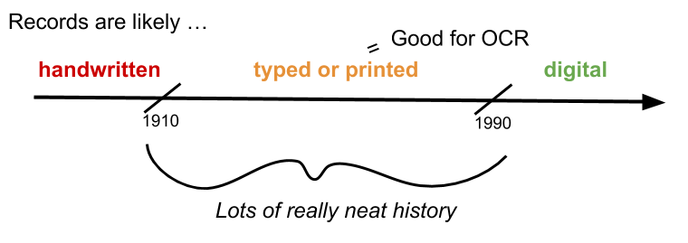

Here’s a brief outline of the OCR workflow:

## Four step approach

- Step one: Scan the document.
- Step two: Apply OCR software.
- Step three: Use patterns in the records to format raw text data.
- Step four: Take advantage of multiple scans to limit errors.

## Scan

Before jumping into the more technical steps of the process, a word on scanning. A substantial portion of typed sources have already been digitised as part of a collaborative project between academic libraries and Google, [hathitrust](https://www.hathitrust.org/). More likely than not, one or more scanned copies of the source you would like to use have already exist. If your source hasn’t yet been scanned, reach out to a librarian before you start scanning hundreds of pages. Librarians can help disseminate the final scanned document, and may even be willing to help in the digitization process.

The scan used in this file is from Hathitrust.

## Applying OCR

Fortunately, the problem of recovering text from a scanned document seems essentially solved.

There are many OCR tools including freeware (Tesseract, Gocr, Ocrad, …) and proprietary software (Adobe, ABBY, …).

Not all OCR software is equivalent. Here’s the output for the first page from Adobe:

```r
head(txt_adobe[txt_adobe$page == 1 , "text"] )
```

```
[1] "                                        CHELSEA             (1)"
[2] "                                           (Two Seats)"
[3] " Election        Electors            Candidate                           Party   Votes"
[4] " 1868            17,408              C.W. Dilke                           L      7,374"
[5] "                                     Sir H.A. Hoare, Bt.                  L      7 ,183"
[6] "                                     W .H. Russell                      .C       4, 177"
```

and the same information read by the free software, GOCR:

```r
head(txt_gocr[txt_gocr$page == 26 , "text"] )
```

```
[1] "      _      _l"
[2] "                              cHElsEA  _1 l"
[3] "                                {T_o S__ti}"
[4] " E ___on      E_ori         _nd__t_                         P_rty      Vot8__"
[5] "1868         17,_          C.W._ilk_                         L         7,374"
[6] "                            SiF H.A. _oare, Bt.                   L         7,18J"
```

For this exercise, I’ll use the software that produced the two best results for this small project: Hathitrust’s application of Tesseract, and Adobe’s OCR utility.

Fortunately, UC Berkeley’s library has Adobe installed on library computers. Here’s a screenshot of Adobe’s OCR in action on a library laptop:

[figure not shown]

## From .txt to .csv

The challenge in applying OCR, then, is recovering the format that the data were originally stored in. The approach here uses patterns in the raw text to identify the rows and columns of interest.

First, let’s make a few observations about the structure of the data: - What information are on each page? Each page has information on electoral outcomes for one county - How are the data formatted? (spaces between columns), the year isn’t repeated, there are interruptions

### Getting rows in order

Notice that the number of rows differs between the two best OCR results. For the adobe file, the number of identified rows is

```
[1] 18173
```

while the same number for the original text from Hathitrust

```
[1] 18253
```

The discrepancy of 80 rows means that the rows in the raw text between the two files do not always point to the same information in the original source. We can begin to address this problem by eliminating rows which seem to be devoid of useful information. In this case, I am removing rows which only contain numbers, spaces, or punctuation.

```r
txt_adobe <- txt_adobe[grepl("[^[:digit:][:space:]]", txt_adobe$text),]
txt_hathi <- txt_hathi[grepl("[^[:digit:][:space:]]", txt_hathi$text),]
txt_adobe <- txt_adobe[grepl("[^[:punct:][:space:]]", txt_adobe$text),]
txt_hathi <- txt_hathi[grepl("[^[:punct:][:space:]]", txt_hathi$text),]
```

*A quick digression:* I used regular expressions here to identify rows which contain characters other than spaces and digits. The line “[^stuff]” finds rows with “any string including something other than stuff.” Regular expressions are a tool for working with character strings that is not (by any means) specific to $R$. Consequently, regular expressions are too large a topic to be explained in this notebook. At the same time, extracting formatted data from raw text relies *very heavily* on regular expressions, so I will use regular expressions below without explanation of what each line means (Apologies!). If you’d like to learn more about regular expressions in $R$, I’d recommend looking [here](http://stat545.com/block022_regular-expression.html) or [here](http://uc-r.github.io/regex).

Before moving further, lets store the raw text in a new variable so that we don’t lose this information in the cleaning process.

```r
txt_adobe$rawtext <- txt_adobe$text
txt_hathi$rawtext <- txt_hathi$text
```

Much of the cleaning process simply involves removing unnecessary information!

```r
# Dropping strange fractional information
txt_adobe$text <- gsub("\\(.+\\)","", txt_adobe$text)
txt_hathi$text <- gsub("\\(.+\\)","", txt_hathi$text)
txt_adobe$text <- gsub("\\[.+\\]","", txt_adobe$text)
txt_hathi$text <- gsub("\\[.+\\]","", txt_hathi$text)
# Dropping column name rows
txt_adobe <- subset(txt_adobe, !grepl("elect|Elect|Vote|vote|party|Party|Candidate|candidate", txt_adobe$text) )
txt_hathi <- subset(txt_hathi, !grepl("elect|Elect|Vote|vote|party|Party|Candidate|candidate", txt_hathi$text) )
# And any other empty rows
txt_adobe <- txt_adobe[grepl("[^[:digit:][:space:]]", txt_adobe$text),]
txt_hathi <- txt_hathi[grepl("[^[:digit:][:space:]]", txt_hathi$text),]
txt_adobe <- txt_adobe[grepl("[^[:punct:][:space:]]", txt_adobe$text),]
txt_hathi <- txt_hathi[grepl("[^[:punct:][:space:]]", txt_hathi$text),]
# Dropping pesky remaining punctuation
txt_adobe$text <- gsub("[[:punct:]]","",txt_adobe$text)
txt_hathi$text <- gsub("[[:punct:]]","",txt_hathi$text)
```

### Extracting page-level information

First, we’ll grab the county name which is listed at the top of each page.

```r
require(dplyr)
# Identifying county and # of electors
txt_adobe %>%
  group_by(page) %>%
  mutate( countyraw = text[1],
          seatsraw = text[2]
        ) %>%
  as.data.frame() -> txt_adobe
txt_hathi %>%
  group_by(page) %>%
  mutate( countyraw = text[1],
          seatsraw = text[2]
        ) %>%
  as.data.frame() -> txt_hathi
# Dropping county and seats text
txt_adobe <- subset(txt_adobe, text != countyraw & text != seatsraw , select = -c(seatsraw) )
txt_hathi <- subset(txt_hathi, text != countyraw & text != seatsraw , select = -c(seatsraw) )
# Cleaning county names
txt_adobe$county <- gsub("\\(.+|\\[.+","", txt_adobe$countyraw)
txt_adobe$county <- gsub("{2,}[[:space:]]","", txt_adobe$county)
txt_adobe <- subset(txt_adobe, select = -c(countyraw))
txt_hathi$county <- gsub("\\(.+|\\[.+","", txt_hathi$countyraw)
txt_hathi$county <- gsub("{2,}[[:space:]]","", txt_hathi$county)
txt_hathi <- subset(txt_hathi, select = -c(countyraw))
# Plotting results
head(summary(as.factor(txt_adobe$county)))
```

```
CITYofLONDON   NOTTINGHAM    DEVONPORT      IPSWICH    CAMBRIDGE   MARYLEBONE
         107           86           76           72           71           71
```

### Finding observations

```r
# counting the number of columns
txt_adobe$columns <- unlist(lapply( strsplit(txt_adobe$text,"  ") , function(x)  length(x[x != ""]) ))
txt_hathi$columns <- unlist(lapply( strsplit(txt_hathi$text,"  ") , function(x)  length(x[x != ""]) ))
# dropping rows with very few columns
txt_adobe <- subset(txt_adobe, columns > 2 )
txt_hathi <- subset(txt_hathi, columns > 1 )
```

```r
# Guessing which rows contain years
txt_adobe$text <- gsub("^[[:blank:]]+","",txt_adobe$text)
txt_adobe$elecrow <- grepl("^{3,4}[[:digit:]]", txt_adobe$text) & txt_adobe$columns > 3
txt_hathi$text <- gsub("^[[:blank:]]+","",txt_hathi$text)
txt_hathi$elecrow <- grepl("^{3,4}[[:digit:]]", txt_hathi$text) & txt_hathi$columns > 1
```

With election rows identified, we can construct an id variable for individual elections.

```r
# Generating page/election ids
txt_adobe %>%
  group_by(page) %>%
  mutate( elecid = page*100 + cumsum(as.numeric(elecrow))  ) %>%
  as.data.frame() -> txt_adobe
txt_hathi %>%
  group_by(page) %>%
  mutate( elecid = page*100 + cumsum(as.numeric(elecrow))  ) %>%
  as.data.frame() -> txt_hathi
```

Great! Now we can separate the election year as a new column,

```r
# Adding guessed election year
txt_adobe %>%
  group_by( elecid ) %>%
  mutate( election = substr(text[1],1,4) )  %>%
  as.data.frame() -> txt_adobe
txt_hathi %>%
  group_by( elecid ) %>%
  mutate( election = substr(text[1],1,4) )  %>%
  as.data.frame() -> txt_hathi
# removing election year from text and dropping bad years
txt_adobe$text[txt_adobe$elecrow] <- gsub("^....","", txt_adobe$text[txt_adobe$elecrow] )
txt_hathi$text[txt_hathi$elecrow] <- gsub("^....","", txt_hathi$text[txt_hathi$elecrow] )
txt_adobe$election <- as.numeric(txt_adobe$election)
txt_adobe$election[txt_adobe$election < 1830 | txt_adobe$election > 1885 ] <- NA
txt_hathi$election <- as.numeric(txt_hathi$election)
txt_hathi$election[txt_hathi$election < 1830 | txt_hathi$election > 1885 ] <- NA
```

and get a first quantitative look at the data:

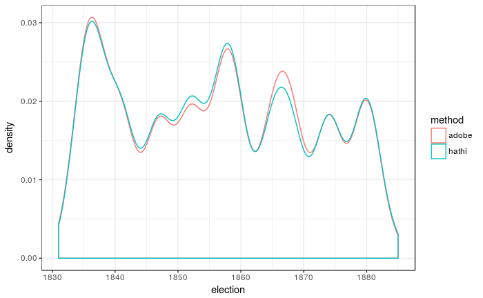

```r
# plotting results
require(ggplot2)
plot_election <- subset(txt_adobe, select = c(election, method))
plot_election <- rbind(plot_election, subset(txt_hathi, select = c(election, method)))
election_year <- ggplot(plot_election, aes(x = election, colour = method )) + geom_density() + theme_bw()
election_year
```

We can see that, although there are transcription errors in each method, the errors seem to be uncorrelated with the election year.

### Finding columns

Now, we can begin to separate out the other columns in the raw text. First, let’s find the number of electors in each county in each year.

```r
# Removing cumbersome spaces between numbers
txt_adobe$text <- gsub("(?<=[[:digit:]])[[:blank:]](?=[[:digit:]])","", txt_adobe$text , perl = TRUE )
txt_hathi$text <- gsub("(?<=[[:digit:]])[[:blank:]](?=[[:digit:]])","", txt_hathi$text , perl = TRUE )
# Extracting the number of electors
txt_adobe$text <- gsub("^[[:blank:]]+","",txt_adobe$text)
txt_adobe$has_electors <- grepl("^\\d+",txt_adobe$text )
txt_adobe$electors <- NA
txt_adobe$electors[txt_adobe$has_electors] <- as.numeric(unlist(lapply(strsplit(txt_adobe$text[txt_adobe$has_electors],"  "), "[[",1 )))
txt_adobe$electors[ txt_adobe$electors > 15000 ] <- NA
txt_adobe$text[txt_adobe$has_electors] <- gsub("^[[:digit:]]+","", txt_adobe$text[txt_adobe$has_electors] )
txt_hathi$text <- gsub("^[[:blank:]]+","",txt_hathi$text)
txt_hathi$has_electors <- grepl("^\\d+",txt_hathi$text )
txt_hathi$electors <- NA
txt_hathi$electors[txt_hathi$has_electors] <- as.numeric(unlist(lapply(strsplit(txt_hathi$text[txt_hathi$has_electors],"  "), "[[",1 )))
txt_hathi$electors[ txt_hathi$electors > 15000 ] <- NA
txt_hathi$text[txt_hathi$has_electors] <- gsub("^[[:digit:]]+","", txt_hathi$text[txt_hathi$has_electors] )
```

And now we can look at the distribution of electors in each sample:

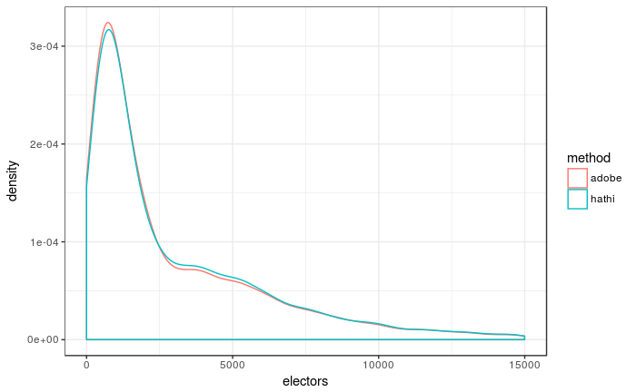

```r
# plotting results
require(ggplot2)
plot_electors <- subset(txt_adobe, select = c(electors, method))
plot_electors <- rbind(plot_electors, subset(txt_hathi, select = c(electors, method)))
elector_density <- ggplot(plot_electors, aes(x = electors, colour = method )) + geom_density() + theme_bw()
elector_density
```

Now we will collect the number of votes received by each candidate:

```r
# Extracting the number of votes received by each candidate
txt_adobe$text <- gsub("[[:blank:]]+$","",txt_adobe$text)
txt_adobe$support <- gsub("[[:space:]]","",str_sub( txt_adobe$text, -6, -1 ))
txt_adobe$votes <- as.numeric(txt_adobe$support)
txt_adobe$contended <- !grepl("uno|unopp|opp|Unopp|Unop",txt_adobe$support)
txt_adobe$text <- str_sub( txt_adobe$text, 1, -6 )
txt_adobe$text <- gsub("[[:blank:]]+$","",txt_adobe$text)
txt_hathi$text <- gsub("[[:blank:]]+$","",txt_hathi$text)
txt_hathi$support <- gsub("[[:space:]]","",str_sub( txt_hathi$text, -6, -1 ))
txt_hathi$votes <- as.numeric(txt_hathi$support)
txt_hathi$contended <- !grepl("uno|unopp|opp|Unopp|Unop",txt_hathi$support)
txt_hathi$text <- str_sub( txt_hathi$text, 1, -6 )
txt_hathi$text <- gsub("[[:blank:]]+$","",txt_hathi$text)
```

Now we can answer the question: did parliamentary elections become more competative over the period?

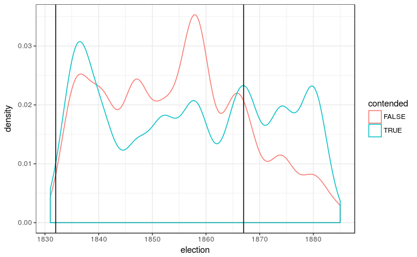

```r
# plotting results
require(ggplot2)
contended <- ggplot(txt_adobe, aes(x = election, colour = contended)) + geom_density() + theme_bw() +
  geom_vline(xintercept = 1832) + geom_vline(xintercept = 1867)
contended
```

Finally, we can identify the political party of each candidate, and store the remaining text as the candidate.

```r
# Extracting the number of votes received by each candidate
txt_adobe$party <- tolower(str_sub( txt_adobe$text, -1, -1 ))
txt_adobe$text <- str_sub( txt_adobe$text, 1, -2 )
txt_adobe$candidate <- gsub("^[[:blank:]]+|[[:blank:]]+$","",txt_adobe$text)
txt_adobe$party[!grepl("l|c", txt_adobe$party) ] <- NA
txt_hathi$party <- tolower(str_sub( txt_hathi$text, -1, -1 ))
txt_hathi$text <- str_sub( txt_hathi$text, 1, -2 )
txt_hathi$candidate <- gsub("^[[:blank:]]+|[[:blank:]]+$","",txt_hathi$text)
txt_hathi$party[!grepl("l|c", txt_hathi$party) ] <- NA
```

### From candidate to County/election panel

Ultimately, I would like an (unbalanced) data set at the level of county/election.

```r
txt_adobe %>%
  group_by(elecid) %>%
  summarize( page = page[1],
             method = method[1],
             county = county[1],
             election = election[1],
             electors = electors[1],
             totalvotes = sum(na.omit(votes)),
             contended = contended[1],
             unopposed_party = party[contended == FALSE][1],
             liberal_votes = sum(na.omit(votes[party == "l"])),
             liberal_candidates = sum(na.omit(party == "l")),
             candidates = n(),
             conservative_votes = sum(na.omit(votes[party == "c"])) ) %>%
  as.data.frame() -> data_adobe
data_adobe$liberal_share <- data_adobe$liberal_votes / data_adobe$totalvotes
data_adobe$liberal_seat <- as.numeric( data_adobe$liberal_votes > data_adobe$conservative_votes )
data_adobe$liberal_seat[data_adobe$unopposed_party == "l"] <- 1
txt_hathi %>%
  group_by(elecid) %>%
  summarize( page = page[1],
             method = method[1],
             county = county[1],
             election = election[1],
             electors = electors[1],
             totalvotes = sum(na.omit(votes)),
             contended = contended[1],
             unopposed_party = party[contended == FALSE][1],
             liberal_votes = sum(na.omit(votes[party == "l"])),
             liberal_candidates = sum(na.omit(party == "l")),
             candidates = n(),
             conservative_votes = sum(na.omit(votes[party == "c"])) ) %>%
  as.data.frame() -> data_hathi
data_hathi$liberal_share <- data_hathi$liberal_votes / data_hathi$totalvotes
data_hathi$liberal_seat <- as.numeric( data_hathi$liberal_votes > data_hathi$conservative_votes )
data_hathi$liberal_seat[data_hathi$unopposed_party == "l"] <- 1
```

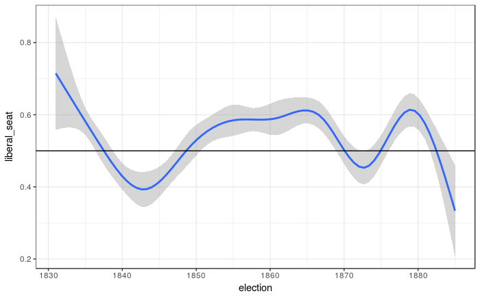

```r
lib <- ggplot(data_adobe, aes(x = election, y = liberal_seat)) +
       theme_bw() + geom_smooth() + geom_hline(yintercept = 0.5, type = 2)
lib
```

## Multiplicity

How do our results compare for each implementation of OCR? To compare transcribed variables, we can merge election/years together.

```r
# generating variable IDs
data_adobe$merge <- paste( as.character(data_adobe$page), as.character(data_adobe$election), sep = " ")
data_hathi$merge <- paste( as.character(data_hathi$page), as.character(data_hathi$election), sep = " ")
# Mergeing
data <- merge(data_adobe, data_hathi, by = "merge", all = TRUE)
```

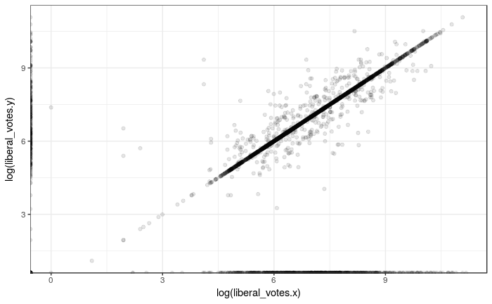

```r
# Checking data quality
test <- ggplot(data, aes(x = log(liberal_votes.x ), y = log(liberal_votes.y ))) + geom_point(alpha = 0.1) + theme_bw()
test
```

We can take advantage of having multiple iterations of the data set. If transcription errors are somewhat independent, then we can take only the best observations from each iteration. There are many ways that we could exploit the multiplicity of our data, but I’ll take a very simple approach here. I’ll keep observations if they are exactly the same for the two years, and prefer one method over another if observations are missing.

```r
varlist <- unique( gsub("\\.x|\\.y" , "", colnames(data[,2:ncol(data)]))  )
for(var in varlist){
varx <- paste(var, "x", sep = "." )
vary <- paste(var, "y", sep = "." )
data[,var] <- NA
good <- which(as.character(data[,varx]) == as.character(data[,vary]))
xbetter <- which(is.na(data[,vary]))
ybetter <- which(is.na(data[,varx]))
data[good,var] <- data[good,varx]
data[xbetter,var] <- data[xbetter,varx]
data[ybetter,var] <- data[ybetter,vary]
}
```

Now we can revisit earlier results

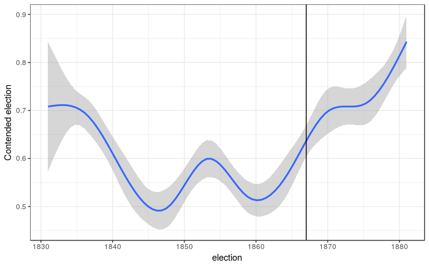